# Sustainable objectives and commitments deceived by fisheries subsidies for ‘temporary cessations’ in times of COVID

Annotated script

05 July 2021.

# 1 Introduction

This RMarkdown document consists in the detailed and annotated R script that support the findings reported in the manuscript “Sustainable objectives and commitments deceived by fisheries subsidies in times of COVID” submitted to Marine Policy. After the review process and if the manuscript is accepted, this document as well as the files attached to it will be made available via a Git-Hub repository.

# 2 Material and Methods

As described in the manuscript, two sets of data were used in this analysis:

1. The list of beneficiaries of the European Maritime and Fisheries Fund (EMFF); and
2. The European fleet register.

Below, we provide details on how each set was cleaned, completed, and prepared for our analysis.

## 2.1 The European Maritime and Fisheries Fund (EMFF)

The list of French EMFF beneficiaries was downloaded at: https://www.europe-en-france.gouv.fr/fr/ressources/liste-des-operations-du-programme-national-feamp-2014-2020 and loaded:

```r
emff <- read_excel("Data/Raw/liste_des_beneficiaires_20201206.xlsx", sheet = 3) #Load France's EMFF data
```

### 2.1.1 Cleaning EMFF records

It was then cleaned before it could be processed. We first selected and renamed the columns of interest:

```r
emff <- emff %>%
  row_to_names(row_number = 5) %>% #Use row 5 to rename columns
  select(axis_code = `Dénomination de la priorité de l'union`, #Select and rename columns of interest
         measure_code = `Code mesure`,
         measure = `Libellé mesure`,
         action_code = `Code sous-\nmesure`,
         action = `Libellé sous-mesure`,
         beneficiary_type = `Code nature bénéficiaire ( P / M )`,
         beneficiary = `Dénomination sociale`,
         project_number = `Numéro de dossier initial`,
         cfr_old = `Numéro de navire`,
         project_name = `Intitulé de l'opération`,
         date = `Date prévisionnelle début d'opération`,
         status = `Libellé état du dossier`,
         subsidy_europe = `Montant EJ FEAMP \n\"part contrepartie\"`,
         subsidy_national = `Montant EJ \n\"part principale\"`)
```

And then modified (i.e. fixed or cleaned) a number of columns:

```r
emff <- emff %>%
  mutate_at(vars(matches(c("subsidy_europe", "subsidy_national"))), ~as.numeric(.)) %>%
  mutate(cfr_old = str_to_upper(cfr_old), #CFRs to upper case for cleaning
         cfr_old = gsub(" ", "", cfr_old), #Remove spaces in CFRs
         date = ifelse(date == "#VALEURMULTI", NA, date), #Remove unknown dates
         date = dmy(date),
         date = as.Date(ifelse(year(date) < 2000, date + years(100), date), origin = lubridate::origin)) #Fix incorrect dates
```

We then proceeded with cleaning CFRs, so they could be matched with the European register:

```r
emff <- emff %>%
  #Set aside records with no CFRs
  filter(is.na(cfr_old)) %>%
  #Deal with records with CFRs
  bind_rows(emff %>%
              filter(!is.na(cfr_old)) %>%
              mutate(cfr = ifelse(grepl("\\FRA000[0-9]{6}", cfr_old), cfr_old, NA))) #Extract clean CFRs
emff <- emff %>%
  #Set aside records with no CFRs or clean CFRs
  filter(is.na(cfr_old) | !is.na(cfr)) %>%
  #Deal with remaining records (i.e. CFRs that need to be cleaned)
  bind_rows(emff %>%
              filter(!is.na(cfr_old) & is.na(cfr)) %>%
              mutate(cfr_old = str_replace(cfr_old, "^([:alpha:]{2,4})?(0{1,3})?([0-9]{2})([:alpha:]{1})?([0-9]{4})([:alpha:]{1,2})?$", "FRA000\\3\\5"),
                     cfr_old = ifelse(project_number == "PFEA310019CR0910004", "FRA000401420", #Immatriculation in project_name
                                      ifelse(project_number == "PFEA310019CR0310004", "FRA000924689", cfr_old)), #http://www.fao.org/figis/vrmf/finder/EU/!/display/vessel/UID/030271047
                     cfr = ifelse(grepl("\\FRA000[0-9]{6}", cfr_old), cfr_old, NA))) #Extract and clean CFRs
```

We then added some extra information. First, we classified as ‘shore fishing’ records whose `project_name` contained `PAP` (i.e. `pêche à pied`, or French for `shore fishing`):

```r
emff <- emff %>%
  mutate(cfr = ifelse(grepl("\\ PAP ", project_name), "Shore fishing", cfr)) %>% #"PAP" = "Pêche à pied" = 'shore fishing' in French
  select(-cfr_old) %>%
  replace_na(list(cfr = "-"))
```

Then removed empty records:

```r
emff <- emff %>%
  filter(!(is.na(subsidy_europe) & !is.na(subsidy_national)) & !(subsidy_europe == 0 & subsidy_national == 0))
```

And classified records as ‘COVID fund’ or not (i.e. `Other funds`):

```r
emff <- emff %>%
  mutate(covid_fund = ifelse(str_detect(project_name, fixed("covid", ignore_case = TRUE)), "COVID fund", "Other funds"),
         subsidy_total = subsidy_europe + subsidy_national) %>%
  replace_na(list(covid_fund = "Other funds"))
```

### 2.1.2 Dealing with duplicates

These data contained a number of duplicates:

| Project | Status |
| --- | --- |
| PFEA411117DM0990001 | En cours de réalisation |
| PFEA411117DM0990001 | Soldé |
| PFEA470017FA1000005 | Réalisé |
| PFEA470017FA1000005 | Soldé |
| PFEA500018CR0720001 | Réalisé |
| PFEA500018CR0720001 | Soldé |
| PFEA510018CR0720004 | Réalisé |
| PFEA510018CR0720004 | Soldé |
| PFEA621218CR0720010 | Réalisé |
| PFEA621218CR0720010 | Soldé |
| PFEA621318CR0910001 | Réalisé |
| PFEA621318CR0910001 | Soldé |
| PFEA621418CR0230001 | Réalisé |
| PFEA621418CR0230001 | Soldé |
| PFEA621418CR0250001 | Réalisé |
| PFEA621418CR0250001 | Soldé |
| PFEA690018DM0980004 | Réalisé |
| PFEA690018DM0980004 | Soldé |
| PFEA700019DM0980001 | Réalisé |
| PFEA700019DM0980001 | Soldé |
| PFEA780218CT0970001 | Réalisé |
| PFEA780218CT0970001 | Soldé |

As seen in the table above, it appears that for all these duplicates, one record is identified as ‘Soldé’, i.e. ‘Settled’. We considered that these records were the correct ones and therefore removed the other ones from our dataset:

```r
emff <- emff %>%
  anti_join(emff %>% #Remove duplicates from dataset
              group_by(project_number) %>%
              mutate(count = n()) %>%
              filter(count > 1) %>%
              arrange(project_number) %>%
              select(-count)) %>%
  bind_rows(emff %>% #Add settled records back in
              group_by(project_number) %>%
              mutate(count = n()) %>%
              filter(count > 1) %>%
              arrange(project_number) %>%
              select(-count) %>%
              filter(status == "Soldé"))
```

### 2.1.3 Adding missing CFRs

Out of the 3,730 operations retained for our analysis, 802 corresponded to the COVID fund. Out of those, CFRs were not available for 222, i.e. 27.7 % of the records and 31.9 % of the amount. Thanks to the information provided in the column `beneficiary`, we were able to reconstruct a number of CFRs so as to strengthen our analyses and reduce the percentage of unknown vessels. To do so, we first extracted the list of beneficiaries and project numbers for which there were no CFRs, and saved it:

```r
write.xlsx(emff %>%
  filter(covid_fund == "COVID fund" & cfr == "-" & !is.na(beneficiary)) %>%
  select(beneficiary, project_number) %>%
  distinct(),
  "Output/Data/List of projects with no CFR - To be cleaned.xlsx")
```

This list was manually cleaned and then loaded back and merged with the clean EMFF records:

```r
emff <- emff %>%
  #Set aside records that already have a CFR, or no CFR and no beneficiary, or funds other than COVID fund
  filter(covid_fund == "Other funds" | (!cfr == "-" | is.na(beneficiary))) %>%
  #Add info for COVID fund records that have no CFR but a beneficiary name
  bind_rows(emff %>%
              filter(covid_fund == "COVID fund" & cfr == "-" & !is.na(beneficiary)) %>%
              select(-cfr) %>%
              left_join(read_excel("Data/Processed/List of projects with no CFR.xlsx", sheet = 1) %>% #Load manually complemented CFRs
                          select(-comment, -source), #Keep these two columns if you want to see comments and sources that justify the new CFRs
                        by = c("beneficiary", "project_number")))
```

As a result of this last step, the number of records with no CFR was reduced to 157, i.e. 19.6 % of the records and 10 % of the amount.

## 2.2 The European fleet register

The EU fleet register (https://webgate.ec.europa.eu/fleet-europa/search_en) — which contains all historical records relating to fishing vessels flagged in EU Member States — was downloaded on 13 January 2021 with the following filters:

- Country: ‘FRA’
- Period: ‘All vessels’
- Search data context: ‘Search data in the whole history of the vessels’

The resulting file, which will be processed below, was loaded:

```r
fleet <- read.csv2("Data/Raw/vesselRegistryListResults.csv", quote = "", stringsAsFactors = FALSE) #Load raw data from EU website
```

### 2.2.1 Cleaning the records

We then proceeded with cleaning and completing the data. First, we selected and renamed the columns of interest:

```r
fleet <- fleet %>%
  select(cfr = CFR, #Rename columns
         vessel_name = Name.of.vessel,
         reg_port = Place.of.registration,
         event_start_date = Event.Start.Date,
         event_end_date = Event.End.Date,
         gear_code = Main.fishing.gear,
         length = LOA,
         tonnage = Tonnage.GT,
         Power.of.main.engine,
         Power.of.auxiliary.engine)
```

And then modified (i.e. fixed or cleaned) a number of columns:

```r
fleet <- fleet %>%
  mutate_at(vars(matches(c("length", "tonnage", "Power.of.main.engine", "Power.of.auxiliary.engine"))), ~as.numeric(.)) %>% #Convert as numeric
  mutate(vessel_name = str_to_upper(vessel_name), #Capitalize vessel_name
         event_start_date = as.Date(event_start_date, origin = "1899-12-30"), #Make dates actual dates
         event_end_date = ifelse(event_end_date == "2100-12-31", "2021-01-13", event_end_date), #Replace last records by download date
         event_end_date = as.Date(event_end_date, origin = "1899-12-30"), #Make dates actual dates
         power = Power.of.main.engine + Power.of.auxiliary.engine) %>% #Combine main and auxiliary power
  select(-Power.of.main.engine, -Power.of.auxiliary.engine) %>%
  replace_na(list(reg_port = "NA")) #`reg_port`= NA corresponds to the port of Nantes, not an NA record
```

We then added the names, types, and categories of fishing gears based on `gear_code`:

```r
fleet <- fleet %>%
  left_join(read_excel("Data/Processed/Gear codes.xlsx"), #Load fishing gear codes to clean register
            by = "gear_code") %>%
  select(vessel_name, reg_port, cfr, gear, gear_cat, gear_type, event_start_date, event_end_date, length, tonnage, power) #Select columns of interest
```

### 2.2.2 Simplifying the records

We then only kept continuous records to facilitate processing later on:

```r
fleet <- setDT(fleet)
fleet <- fleet[,.(event_start_date = min(event_start_date),
          event_end_date = max(event_end_date)) ,
       by = .(rleid(cfr, vessel_name, reg_port, length, tonnage, power, gear, gear_cat, gear_type),
            cfr,
            vessel_name,
            reg_port,
            length,
            tonnage,
            power,
            gear,
            gear_cat,
            gear_type)] %>%
  select(-rleid)
```

### 2.2.3 Categorizing information

We created two columns:

1. A `last_event` column, with either a `TRUE` (‘last event’) or `FALSE` (‘older event’) value;
2. A `covid_fund_period_overlap` column, with either a `TRUE` (‘overlapping the COVID fund period’) or `FALSE` (‘not overlapping’) value:

```r
fleet <- fleet %>%
  group_by(cfr) %>%
  arrange(desc(event_start_date)) %>%
  mutate(last_event = as.logical(row_number() == 1)) %>%
  ungroup() %>%
  mutate(covid_fund_period_overlap = int_overlaps(interval(event_start_date, event_end_date), interval(ymd("2020-03-12"), ymd("2020-05-31"))))
```

### 2.2.4 Creating length, tonnage, and power classes

We then extracted the fleet that was active during the period covered by the COVID fund:

```r
covid_fleet <- fleet %>%
  filter(covid_fund_period_overlap == TRUE) %>%
  group_by(cfr) %>%
  arrange(cfr, desc(event_start_date)) %>% #Filter most recent event (i.e. not necessarily a `last_event` == TRUE record...)
  filter(row_number() == 1) %>%
  select(-covid_fund_period_overlap) %>%
  ungroup()
```

And created length classes based on i) those provided in the COVID fund decree, and ii) the official French classification:

```r
covid_fleet <- covid_fleet %>%
  mutate(class_length = ifelse(length < 10, "<10 m", #The COVID fund decree distinguishes vessels with a length <10 m from those in the 10-12 m class
                        ifelse(length >=10 & length <12, "10-12 m", #See above
                               ifelse(length >= 12 & length < 25, "12-25 m", #Official FranceAgriMer classification
                                      ifelse(length >= 25 & length < 40, "25-40 m", ">40 m")))), #Official FranceAgriMer classification
         class_length = fct_reorder(class_length, length))
```

Based on these classes, we also created tonnage and power classes, each class containing a number of records based on `class_length`’s proportions.

```r
#Calculate quantiles
quantiles <- covid_fleet %>%
  group_by(class_length) %>%
  summarise(class_length = n()) %>%
  mutate(class_length = cumsum(class_length / nrow(covid_fleet))) %>%
  select(class_length) %>%
  add_row(class_length = 0, .before = 1) %>%
  pull()

#Apply quantiles to tonnage and power
list <- c("tonnage", "power")
datalist = list()
for(i in seq_along(list))
{
  df <- covid_fleet %>%
    select(i = list[i]) %>%
    mutate(i = quantcut(i, q = quantiles, dig.lab = 5))
  #Store breaks for later use
  breaks <- df  %>%
    distinct() %>%
    mutate(i = str_split(gsub("[][(]",
                              "",
                              i),
                         ",")) %>%
    unnest(cols = c(i)) %>%
    mutate(i = round(as.numeric(i), 2),
           i = ifelse(i == min(i), 0, i)) %>%
    distinct() %>%
    arrange(i)
  colnames(breaks)[1] <- paste("break_", list[i], sep = "")
  colnames(df)[1] <- paste("break_", list[i], sep = "")
  assign(colnames(df)[1], breaks) #Rename dataframe with breaks
  datalist[[i]] <- df # add breaks to list
  rm(breaks, df)
}
covid_fleet <- bind_cols(covid_fleet, datalist) #Put data together

#Create proper classes and factorize them
list <- c("break_tonnage", "break_power")
datalist = list()
for(i in seq_along(list))
{
  df <- covid_fleet %>%
    select(i = list[i]) %>%
    distinct()
  df <- df %>%
    mutate(j = ifelse(i == first(levels(i)),
                      paste("<",
                            df %>%
                              filter(i == first(levels(i))) %>%
                              mutate(x = str_sub(i, 2, -2)) %>%
                              separate(x, c("min", "max"), sep = ",") %>%
                              mutate_at(vars(matches(c("min", "max"))), ~round(as.numeric(.), 0)) %>%
                              select(max) %>%
                              pull(),
                            sep = ""),
                      NA))
  df <- df %>% #Deal with NAs for class_tonnage in data above
    filter(!is.na(j)) %>%
    bind_rows(df %>%
                filter(is.na(j)) %>%
                mutate(j = ifelse(i == last(levels(i)),
                                  paste(">",
                                        df %>%
                                          filter(i == last(levels(i))) %>%
                                          mutate(x = str_sub(i, 2, -2)) %>%
                                          separate(x, c("min", "max"), sep = ",") %>%
                                          mutate_at(vars(matches(c("min", "max"))), ~round(as.numeric(.), 0)) %>%
                                          select(min) %>%
                                          pull(),
                                        sep = ""),
                                  NA)))
  df <- df %>% #Deal with NAs for class_tonnage in data above
    filter(!is.na(j)) %>%
    bind_rows(df %>%
                filter(is.na(j)) %>%
                mutate(j = str_sub(i, 2, -2)) %>%
                separate(j, c("min", "max"), sep = ",") %>%
                mutate_at(vars(matches(c("min", "max"))), ~round(as.numeric(.), 0)) %>%
                mutate(j = paste(min, "-", max, sep = "")) %>%
                select(-min, -max))
  #Store factors for later use
  factors <- df %>%
    arrange(i) %>%
    mutate(id = 1:n()) %>%
    select(-i) %>%
    mutate(j = fct_reorder(j, id))
  colnames(df)[2] <- list[i]
  colnames(df)[2] = gsub("break", "class", colnames(df)[2])
  colnames(factors)[1] <- colnames(df)[2]
  assign(colnames(df)[2], factors) #Rename dataframe with breaks
  colnames(df)[1] <- list[i]
  datalist[[i]] <- df # add classes to list
  rm(factors, df)
}
covid_fleet <- covid_fleet %>% #Put data together
  left_join(as.data.frame(datalist) %>%
              select(break_tonnage, class_tonnage),
            by = "break_tonnage") %>%
  left_join(as.data.frame(datalist) %>%
              select(break_power, class_power),
            by = "break_power") %>%
  select(-break_tonnage, -break_power) %>%
  mutate(class_tonnage = paste(class_tonnage, " GT", sep = ""),
         class_power = paste(class_power, " kW", sep = "")) %>%
  mutate(class_tonnage = fct_reorder(class_tonnage, tonnage), #Factorize classes
         class_power = fct_reorder(class_power, power))

#Clean factors for later use
factors_length <- covid_fleet %>%
  select(class_length) %>%
  distinct() %>%
  arrange(class_length) %>%
  mutate(id = 1:n())
factors_tonnage <- class_tonnage %>%
  mutate(class_tonnage = paste(class_tonnage, " GT", sep = ""),
         class_tonnage = fct_reorder(class_tonnage, id))
factors_power <- class_power %>%
  mutate(class_power = paste(class_power, " kW", sep = ""),
         class_power = fct_reorder(class_power, id))
rm(class_power, class_tonnage, datalist, i, list, quantiles)
```

We then used the same classes for the entire fleet:

```r
fleet <- fleet %>%
  mutate(id = as.numeric(cut(tonnage,
                    breaks = break_tonnage %>% select(break_tonnage) %>% pull())))
fleet <- fleet %>%
  filter(!is.na(id)) %>%
  bind_rows(fleet %>%
              filter(is.na(id)) %>%
              mutate(id = ifelse(tonnage == 0, 1,
                                   ifelse(tonnage > 0, fleet %>%
                                            filter(!is.na(id)) %>%
                                            summarise(id = max(id)) %>%
                                            pull(),
                                          NA)))) %>%
  left_join(factors_tonnage, by = "id") %>%
  select(-id)
fleet <- fleet %>%
  mutate(id = as.numeric(cut(power,
                    breaks = break_power %>% select(break_power) %>% pull())))
fleet <- fleet %>%
  filter(!is.na(id)) %>%
  bind_rows(fleet %>%
              filter(is.na(id)) %>%
              mutate(id = ifelse(power == 0, 1,
                                   ifelse(power > 0, fleet %>%
                                            filter(!is.na(id)) %>%
                                            summarise(id = max(id)) %>%
                                            pull(),
                                          NA)))) %>%
  left_join(factors_power, by = "id") %>%
  select(-id)
fleet <- fleet %>%
  mutate(class_length = ifelse(length < 10, "<10 m", #The COVID fund decree distinguishes vessels with a length <10 m from those in the 10-12 m class
                        ifelse(length >=10 & length <12, "10-12 m", #See above
                               ifelse(length >= 12 & length < 25, "12-25 m", #Official FranceAgriMer classification
                                      ifelse(length >= 25 & length < 40, "25-40 m", ">40 m")))), #Official FranceAgriMer classification
         class_length = fct_reorder(class_length, length))
```

As a result, we obtained two files that consisted in:

1. 54,584 records for the entire fleet;
2. 6,257 records for the COVID fleet.

## 2.3 Combining EMFF data with the European register

### 2.3.1 Matching vessels

Before proceeding with matching data, we manually added characteristics for one beneficiary, for which we did not have a CFR, but for which we were able to determine the vessels’ characteristics (see `Data/Processed/List of projects with no CFR.xlsx`)

```r
data <- emff %>%
  filter(!covid_fund == "COVID fund" | !cfr == "-") %>% #Non COVID funds or COVID funds with CFRs
  bind_rows(emff %>% #Deal with other rows
              filter(covid_fund == "COVID fund" & cfr == "-") %>% #Select COVID funds records with no CFR
              left_join(fleet, by = "cfr") %>% #Add columns with vessel characteristics
              mutate(type = "No CFR",
                     class_length = ifelse(beneficiary == "SARL ETOILE D'ARVOR", "12-25 m", class_length))) #Manually add characteristics
```

For the other records, i.e. those with a CFR, we then sequentially matched data from the Register:

#### 2.3.1.1 Matching records with the Register’s records corresponding to the most recent entries that overlapped with the COVID fund

```r
data <- data %>%
  filter(!covid_fund == "COVID fund" | cfr == "-") %>% #Non COVID funds or COVID funds without CFRs
  bind_rows(data %>% #Deal with COVID funds with CFRs
              filter(covid_fund == "COVID fund" & !cfr == "-") %>%
              select(-c(vessel_name:ncol(.))) %>%
              left_join(fleet %>%
                          filter(last_event == TRUE & covid_fund_period_overlap == TRUE),
                        by = "cfr")) %>%
  mutate(type = ifelse(!is.na(class_length) & is.na(type), "CFRs that matched the Register's last events, which overlapped with COVID fund", type))
```

#### 2.3.1.2 Matching remaining records with the Register’s records corresponding to older entries that overlapped with the COVID fund

```r
data <- data %>%
  filter(!covid_fund == "COVID fund" | !(covid_fund == "COVID fund" & !cfr == "-" & is.na(vessel_name))) %>% #Non COVID funds or COVID funds with CFRs that haven't matched yet
  bind_rows(data %>% #Deal with COVID funds with CFRs that haven't matched yet
              filter(covid_fund == "COVID fund" & !cfr == "-" & is.na(vessel_name)) %>%
              select(-c(vessel_name:ncol(.))) %>%
              left_join(fleet %>%
                          filter(last_event == FALSE & covid_fund_period_overlap == TRUE),
                        by = "cfr")) %>%
  mutate(type = ifelse(!is.na(class_length) & is.na(type), "CFRs that matched the Register's older events, which overlapped with COVID fund", type))
```

#### 2.3.1.3 Matching remaining records with the other Register’s records, i.e. those that did not overlap with the COVID fund

```r
data <- data %>%
  filter(!covid_fund == "COVID fund" | !(covid_fund == "COVID fund" & !cfr == "-" & is.na(vessel_name))) %>% #Non COVID funds or COVID funds with CFRs that haven't matched yet
  bind_rows(data %>% #Deal with COVID funds with CFRs that haven't matched yet
              filter(covid_fund == "COVID fund" & !cfr == "-" & is.na(vessel_name)) %>%
              select(-c(vessel_name:ncol(.))) %>%
              left_join(fleet %>%
                          filter(!covid_fund_period_overlap == TRUE),
                        by = "cfr")) %>%
  mutate(type = ifelse(!is.na(class_length) & is.na(type), "CFRs that matched Register's events that did not overlap with COVID fund", type))
```

### 2.3.2 Reconstructing characteristics for non-matching vessels

A few vessels still did not match the Register, but several of these vessels had a `beneficiary` name that we used to reconstruct a correct CFR:

| Beneficiary |
| --- |
| CAP FAGNET |
| EUROPECHE |
| MAY-LINE |

- CAP FAGNET is a company that appears to have owned two vessels in the past: SPES and SYMBIOSE (https://lemarin.ouest-france.fr/secteurs-activites/peche/27319-normandie-un-chalutier-surgelateur-passe-sous-pavillon-francais). SPES is still active and given that its CFR, i.e. FRA000716582, is very close to one for CAP FAGNET that did not match, i.e. FRA000716782, we considered the former to be the correct CFR.
- EUROPECHE is a company that owns vessel SAINT PAUL (CFR is FRA000806962; source: “Le guide de l’armement à la pêche” published by Le Marin). Its registration port, Ouistreham, is consistent for both sources.
- MAY-LINE is a company whose owner (https://www.societe.com/societe/may-line-832966998.html) possesses vessel LA PETITE MAYLIS (FRA000686467; source: “Le guide de l’armement à la pêche” published by Le Marin).

Note that EUROPECHE and MAY-LINE were both incorrectly recorded by the French administration with the same CFR, i.e. FRA000987567, which also appears to be shared by 10 other vessels whose beneficiary are unknown:

| Project number | CFR |
| --- | --- |
| PFEA330020DM0250020 | FRA000987567 |
| PFEA330020DM0250024 | FRA000987567 |
| PFEA330020DM0250031 | FRA000987567 |
| PFEA330020DM0250037 | FRA000987567 |
| PFEA330020DM0250040 | FRA000987567 |
| PFEA330020DM0250049 | FRA000987567 |
| PFEA330020DM0250067 | FRA000987567 |
| PFEA330020DM0250108 | FRA000987567 |
| PFEA330020DM0250026 | FRA000987567 |
| PFEA330020DM0250046 | FRA000987567 |

Based on the above, we cleaned the records for these three vessels with a known beneficiary, and matched them to the Register:

```r
data <- data %>%
  filter(!(beneficiary == "CAP FAGNET" & cfr == "FRA000716782") & !beneficiary %in% c("EUROPECHE", "MAY-LINE")) %>%
  bind_rows(data %>%
              filter((beneficiary == "CAP FAGNET" & cfr == "FRA000716782") | beneficiary %in% c("EUROPECHE", "MAY-LINE")) %>%
              select(-c(vessel_name:ncol(.))) %>%
              mutate(cfr = ifelse(beneficiary == "CAP FAGNET" & cfr == "FRA000716782", "FRA000716582", #Cleaning CFRs
                                  ifelse(beneficiary == "EUROPECHE", "FRA000806962", "FRA000686467"))) %>%
              left_join(fleet %>%
                          filter(last_event == TRUE & covid_fund_period_overlap == TRUE),
                        by = "cfr")) %>%
  select(-last_event, -event_start_date, -event_end_date) %>% #Remove useless columns
  mutate(type = ifelse(!is.na(class_length) & is.na(type), "CFRs that matched the Register's last events, which overlapped with COVID fund",
                       ifelse(!is.na(cfr) & !cfr == "-" & is.na(class_length), "CFRs that did not match any of the Register's events", type)))
```

Finally, we created a ‘Shore fishing’ category for the concerned records:

```r
data <- data %>%
  mutate(type = ifelse(cfr == "Shore fishing", "Shore fishing", type))
```

### 2.3.3 Cleaning columns

Once the records were matched to the vessels’ characteristics, we cleaned a number of columns:

```r
data <- data %>%
  filter(!covid_fund == "COVID fund") %>%
  bind_rows(data %>%
              filter(covid_fund == "COVID fund") %>%
              mutate_at(vars(matches(c("gear", "gear_cat", "gear_type", "class_length", "class_tonnage", "class_power"))), ~ifelse(type == "No CFR" & is.na(class_length), "No CFR", as.character(.))) %>% #Clean columns when there is no CFR and no vessel characteristics
              mutate_at(vars(matches(c("gear", "gear_cat", "gear_type", "class_tonnage", "class_power"))), ~ifelse(type == "No CFR" & !is.na(class_length), "No CFR", as.character(.))) %>% #Clean columns when there is no CFR but vessel characteristics
              mutate_at(vars(matches(c("gear", "gear_cat", "gear_type", "class_length", "class_tonnage", "class_power"))), ~ifelse(type == "CFRs that did not match any of the Register's events", "Unknown vessels", as.character(.))) %>% #Clean columns for unknown vessels
              mutate_at(vars(matches(c("gear", "gear_cat", "gear_type", "class_length", "class_tonnage", "class_power"))), ~ifelse(type == "Shore fishing", "Shore fishing", as.character(.)))) %>% #Clean columns for shore fishing
  mutate_at(vars(matches(c("gear", "gear_cat", "gear_type", "class_length", "class_tonnage", "class_power", "type"))), ~ifelse(!covid_fund == "COVID fund", NA, as.character(.))) #Remove any potential information for 'Other funds' (no impact on results; just a way to clean data as these other funds are out of scope)

#Re-factor classes
factors_length <- factors_length %>%
  bind_rows(tibble(class_length = c("Unknown vessels", "No CFR", "Shore fishing", NA), #Add missing factors
            id = c(6:9))) %>%
  arrange(id)
factors_tonnage <- factors_tonnage %>%
  bind_rows(tibble(class_tonnage = c("Unknown vessels", "No CFR", "Shore fishing", NA), #Add missing factors
            id = c(6:9))) %>%
  arrange(id)
factors_power <- factors_power %>%
  bind_rows(tibble(class_power = c("Unknown vessels", "No CFR", "Shore fishing", NA), #Add missing factors
            id = c(6:9))) %>%
  arrange(id)

data <- data %>%
  mutate(class_length = factor(class_length,
                               levels = factors_length %>%
                                 select(class_length) %>%
                                 distinct() %>%
                                 pull()),
         class_tonnage = factor(class_tonnage,
                                levels = factors_tonnage %>%
                                  select(class_tonnage) %>%
                                  distinct() %>%
                                  pull()),
         class_power = factor(class_power,
                              levels = factors_power %>%
                                select(class_power) %>%
                                distinct() %>%
                                pull()))
```

### 2.3.4 Adding major companies/groups

We extracted the list of `project_number`, `beneficiary` and `vessel_name` combinations that accounted for 30 % of the cumulated subsidies, in order to manually assign the companies that own them:

```r
write.xlsx(data %>%
  filter(covid_fund == "COVID fund") %>%
  arrange(desc(subsidy_total)) %>%
  mutate(cum_sum_percent = cumsum(subsidy_total)/sum(subsidy_total)) %>%
  filter(cum_sum_percent <= 0.3 & (!is.na(beneficiary) | !is.na(vessel_name))) %>%
  select(project_number, beneficiary, vessel_name, cfr) %>%
  distinct() %>%
  mutate(top_30_percent_subsidies = "Yes"),
  "Output/Data/Big companies - To be cleaned.xlsx") #Export data
```

For the 13 companies that were identified in this list, we also manually searched for the complete list of vessels they owned. We merged both files (i.e. the incomplete list and the complete list) with our data in order to assign the concerned vessels to their companies:

```r
data <- data %>%
  left_join(bind_rows(read_excel("Data/Processed/Big companies.xlsx") %>% #Load clean data
                        select(vessel_name, cfr, company) %>%
                        filter(!company == "-"),
                      read_excel("Data/Processed/Big companies - Full list.xlsx") %>% #Load clean data
                        select(vessel_name, cfr, company)) %>%
              distinct(),
            by = c("vessel_name", "cfr"))
```

Overall, France’s list of EMFF beneficiaries amounted to 419.8 million EUR, out of which 17.1 million EUR were from the COVID fund (i.e. 4.1 %). In the present analysis, we focus on the 14.8 million EUR, i.e. 86.5 % of the COVID fund, for which vessels were correctly linked to the European fleet register (i.e. excluding non-matching or missing CFRs, as well as shore fishing).

# 3 Results

For the following analyses, we only kept data pertaining to the COVID fund, as well as vessels for which we had a gear category (i.e. we excluded unknown vessels as well as shore fishing):

```r
data <- data %>%
  filter(covid_fund == "COVID fund" & !(gear_cat %in% c("No CFR", "Unknown vessels", "Shore fishing")))
```

## 3.1 The major groups’ jackpot

### 3.1.1 Preparing the data

We summarized our data to visualize major companies vs. other beneficiaries:

```r
totals <- data %>%
  mutate(big_companies = ifelse(!is.na(company), "Large companies/groups", "Other beneficiaries")) %>%
  group_by(big_companies) %>%
  summarise(subsidy_total = sum(subsidy_total), .groups = "keep")
total_others <- totals %>%
  filter(big_companies == "Other beneficiaries") %>%
  pull()
total_big_companies <- totals %>%
  filter(big_companies == "Large companies/groups") %>%
  pull()
total_seven_big_companies <- data %>%
  mutate(big_companies = ifelse(!is.na(company), "Large companies/groups", "Other beneficiaries")) %>%
  group_by(company, big_companies) %>%
  summarise(subsidy_total = sum(subsidy_total), .groups = "keep") %>%
  filter(big_companies == "Large companies/groups") %>%
  arrange(desc(subsidy_total)) %>%
  ungroup() %>%
  top_n(7) %>%
  summarise(subsidy_total = sum(subsidy_total)) %>%
  pull()
labels <- data %>%
  mutate(big_companies = ifelse(!is.na(company), "Large companies/groups", "Other beneficiaries")) %>%
  group_by(company, big_companies) %>%
  summarise(subsidy_total = sum(subsidy_total), .groups = "keep") %>%
  arrange(subsidy_total) %>%
  ungroup() %>%
  mutate(id = 1:n(),
         company = ifelse(id < 7, NA, as.character(company))) %>%
  filter(!is.na(company)) %>%
  mutate(company = factor(company, levels = unique(.$company)),
         x = 1) %>%
  select(-big_companies)
```

### 3.1.2 Plotting the data

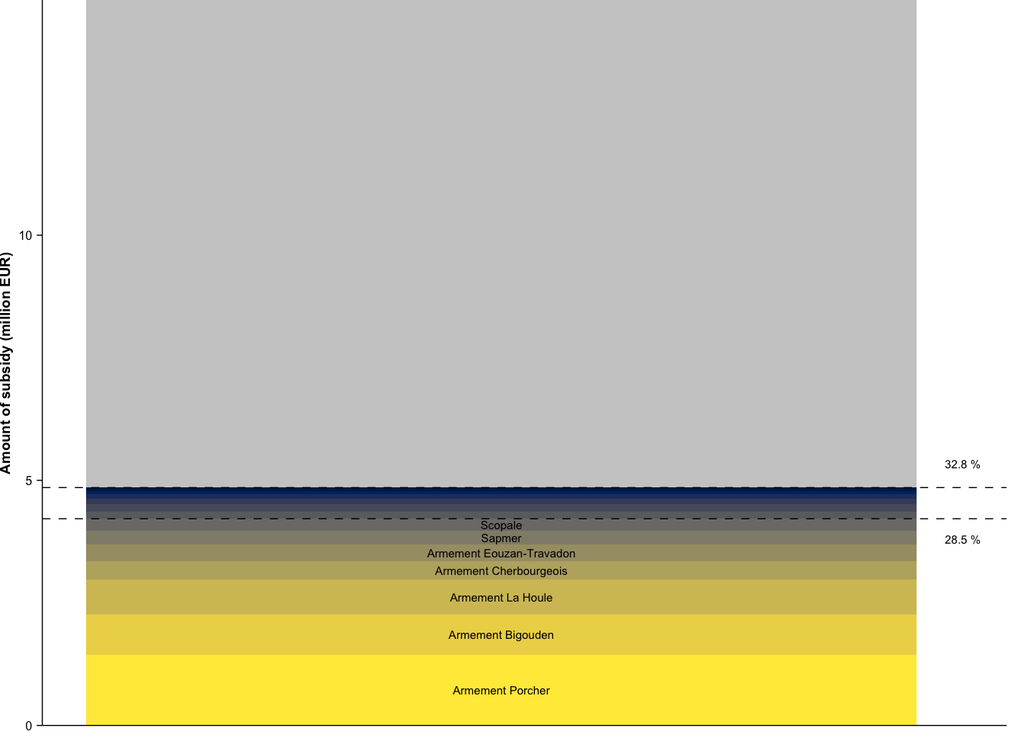

### 3.1.3 Summarizing the data

We show that the 13 companies that we identified received 32.8 % of all allocated subsidies. Among these 13 companies, seven of them accounted for most subsidies, and overall accounted for 28.5 % of all allocated subsidies.

[output not shown]

The 53 vessels owned by these seven companies account for 0.8 % of the French fleet.

## 3.2 Most subsidies benefited larger vessels and higher-impact fishing methods

### 3.2.1 Preparing the data

We first calculated the proportion of subsidies allocated to each gear and length class, in terms of i) number of files processed, total length/tonnage/power of the vessels, and total value of the subsidies received:

```r
#Create function to calculate proportions
proportions_by_class <- function(data){
  df <- data %>%
    summarise(subsidies_number = n(),
              subsidies_length = sum(length),
              subsidies_tonnage = sum(tonnage),
              subsidies_power = sum(power),
              subsidies_value = sum(subsidy_total),
              .groups = "keep") %>%
    ungroup() %>%
    mutate(subsidies_number_percent = subsidies_number/sum(subsidies_number),
           subsidies_length_percent = subsidies_length/sum(subsidies_length),
           subsidies_tonnage_percent = subsidies_tonnage/sum(subsidies_tonnage),
           subsidies_power_percent = subsidies_power/sum(subsidies_power),
           subsidies_value_percent = subsidies_value/sum(subsidies_value))
}
#Apply function
funding_vs_fleet_gear_for_table <- funding_vs_fleet_gear <- proportions_by_class(data %>%
                                                                                   group_by(gear_cat, gear_type)) %>%
  rename(category = gear_cat,
         category_group = gear_type)
funding_vs_fleet_class_length_for_table <- funding_vs_fleet_class_length <- proportions_by_class(data %>%
                                                                                                   group_by(class_length)) %>%
  mutate(category_group = NA) %>% #Create empty group for function below
  rename(category = class_length)
```

We then matched these proportions to those of the actual fleet, pivoted the data into longer format, and prepared the data for plotting. The first step was to summarise the COVID fleet in terms of gear and length class:

```r
#Create function to summarise COVID fleet
summarise_fleet <- function(data){
  data %>%
    summarise(fleet_number = n(),
              fleet_length = sum(length),
              fleet_tonnage = sum(tonnage),
              fleet_power = sum(power),
              .groups = "keep") %>%
    ungroup() %>%
    mutate(fleet_number_percent = fleet_number/sum(fleet_number),
           fleet_length_percent = fleet_length/sum(fleet_length),
           fleet_tonnage_percent = fleet_tonnage/sum(fleet_tonnage),
           fleet_power_percent = fleet_power/sum(fleet_power))
}
#Apply function
covid_fleet_gear <- summarise_fleet(covid_fleet %>%
                                      group_by(gear_cat, gear_type)) %>%
  rename(category = gear_cat,
         category_group = gear_type)
covid_fleet_class_length <- summarise_fleet(covid_fleet %>%
                                              group_by(class_length)) %>%
  mutate(category_group = NA) %>% #Create empty group for function below
  rename(category = class_length)
```

We then merged both sets of data (i.e. subsidies proportions and fleet proportions) and pivoted the data:

```r
#Merge with data
merge_proportions <- function(df1, df2, group1, group2){
  df1 %>%
    full_join(df2, by = c(group1, group2)) %>%
    replace(is.na(.), 0) %>%
    transmute(category = category,
              category_group = category_group,
              subsidies_number = subsidies_number,
              subsidies_length = subsidies_length/10^3,
              subsidies_tonnage = subsidies_tonnage/10^3,
              subsidies_power = subsidies_power/10^3,
              subsidies_value = subsidies_value/10^6,
              dev_number = (subsidies_number_percent / fleet_number_percent) - 1,
              dev_length = (subsidies_length_percent / fleet_length_percent) - 1,
              dev_tonnage = (subsidies_tonnage_percent / fleet_tonnage_percent) - 1,
              dev_power = (subsidies_power_percent / fleet_power_percent) - 1,
              dev_value_number = (subsidies_value_percent / fleet_number_percent) - 1,
              dev_value_length = (subsidies_value_percent / fleet_length_percent) - 1,
              dev_value_tonnage = (subsidies_value_percent / fleet_tonnage_percent) - 1,
              dev_value_power = (subsidies_value_percent / fleet_power_percent) - 1) %>%
    pivot_longer(cols = c(3:ncol(.)),
                 names_to = "type",
                 values_to = "value") %>%
    mutate(unit = ifelse(grepl("value", type), "In value (million EUR)",
                         ifelse(grepl("length", type), "In total length (thousand m)",
                                ifelse(grepl("tonnage", type), "In total tonnage (thousand GT)",
                                       ifelse(grepl("power", type), "In total power (thousand kW)", "In number of files")))))
}
#Apply function
funding_vs_fleet_gear <- merge_proportions(funding_vs_fleet_gear, covid_fleet_gear, "category", "category_group")
funding_vs_fleet_class_length <- merge_proportions(funding_vs_fleet_class_length, covid_fleet_class_length, "category", "category_group")
```

Finally, we prepared the data for plotting:

```r
#Create function to prepare deviation data
deviation <- function(data){
  data %>%
  mutate(type = ifelse(grepl("subsidies", type), "subsidies", "deviation")) %>%
  pivot_wider(names_from = type,
              values_from = value)
}

#Apply function and create final datasets for plotting deviation for different parameters, by gear and length class
funding_vs_fleet_number <- deviation(funding_vs_fleet_gear %>%
                                       filter(grepl("_number$", type) | grepl("_value$", type))) %>%
  mutate(category_group = factor(category_group, levels = c("Passive gears", "Active gears", "Undet.")),
         category = factor(category, levels = funding_vs_fleet_gear %>% filter(type == "dev_number" & unit == "In number of files") %>% arrange(value) %>% select(category) %>% pull()),
         group = "By fishing gear") %>%
  bind_rows(deviation(funding_vs_fleet_class_length %>%
                        filter(grepl("_number$", type) | grepl("_value$", type))) %>%
              mutate(group = "By length class",
                     category = factor(category, levels = c("<10 m", "10-12 m", "12-25 m", "25-40 m", ">40 m")),
                     category_group = NA) %>%
              arrange(category))

funding_vs_fleet_length <- deviation(funding_vs_fleet_gear %>%
                                       filter(grepl("_length$", type) | grepl("_value$", type))) %>%
  mutate(category_group = factor(category_group, levels = c("Passive gears", "Active gears", "Undet.")),
         category = factor(category, levels = funding_vs_fleet_gear %>% filter(type == "dev_length" & unit == "In total length (thousand m)") %>% arrange(value) %>% select(category) %>% pull()),
         group = "By fishing gear") %>%
  bind_rows(deviation(funding_vs_fleet_class_length %>%
                        filter(grepl("_length$", type) | grepl("_value$", type))) %>%
              mutate(group = "By length class",
                     category = factor(category, levels = c("<10 m", "10-12 m", "12-25 m", "25-40 m", ">40 m")),
                     category_group = NA) %>%
              arrange(category))

funding_vs_fleet_tonnage <- deviation(funding_vs_fleet_gear %>%
                                       filter(grepl("_tonnage$", type) | grepl("_value$", type))) %>%
  mutate(category_group = factor(category_group, levels = c("Passive gears", "Active gears", "Undet.")),
         category = factor(category, levels = funding_vs_fleet_gear %>% filter(type == "dev_tonnage" & unit == "In total tonnage (thousand GT)") %>% arrange(value) %>% select(category) %>% pull()),
         group = "By fishing gear") %>%
  bind_rows(deviation(funding_vs_fleet_class_length %>%
                        filter(grepl("tonnage$", type) | grepl("_value$", type))) %>%
              mutate(group = "By length class",
                     category = factor(category, levels = c("<10 m", "10-12 m", "12-25 m", "25-40 m", ">40 m")),
                     category_group = NA) %>%
              arrange(category))

funding_vs_fleet_power <- deviation(funding_vs_fleet_gear %>%
                                       filter(grepl("power$", type) | grepl("_value$", type))) %>%
  mutate(category_group = factor(category_group, levels = c("Passive gears", "Active gears", "Undet.")),
         category = factor(category, levels = funding_vs_fleet_gear %>% filter(type == "dev_power" & unit == "In total power (thousand kW)") %>% arrange(value) %>% select(category) %>% pull()),
         group = "By fishing gear") %>%
  bind_rows(deviation(funding_vs_fleet_class_length %>%
                        filter(grepl("power$", type) | grepl("_value$", type))) %>%
              mutate(group = "By length class",
                     category = factor(category, levels = c("<10 m", "10-12 m", "12-25 m", "25-40 m", ">40 m")),
                     category_group = NA) %>%
              arrange(category))
```

### 3.2.2 Plotting the data

The table below shows a summary of the French fleet in terms of fishing gear and length class, compared to the allocation of the COVID fund (in terms of number of files processed and subsidies allocated), from which we derived the ‘deviation’ indicator plotted below:

| Category | Vessels in French fleet* | Allocation of COVID fund Files processed | Allocation of COVID fund Subsidies (EUR) |
| --- | --- | --- | --- |
| **Fishing gear** |  |  |  |
| Bottom trawls & dredges | 1 062 (17 %) | 324 (56.4 %) | 10 035 804 (67.8 %) |
| Pelagic trawls & seines | 237 (3.8 %) | 37 (6.4 %) | 1 279 772 (8.6 %) |
| Undet. trawls | 85 (1.4 %) | 15 (2.6 %) | 894 823 (6 %) |
| Entangling nets | 1 990 (31.8 %) | 105 (18.3 %) | 1 649 529 (11.1 %) |
| Pots & traps | 1 715 (27.4 %) | 39 (6.8 %) | 419 454 (2.8 %) |
| Hook & lines | 613 (9.8 %) | 10 (1.7 %) | 129 674 (0.9 %) |
| Longlines | 502 (8 %) | 43 (7.5 %) | 384 715 (2.6 %) |
| Undet. | 2 (0 %) | 1 (0.2 %) | 3 811 (0 %) |
| **Length class** |  |  |  |
| <10 m | 4 466 (71.4 %) | 105 (18.3 %) | 792 463 (5.4 %) |
| 10-12 m | 914 (14.6 %) | 169 (29.4 %) | 2 280 224 (15.4 %) |
| 12-25 m | 765 (12.2 %) | 293 (51 %) | 11 114 358 (75.1 %) |
| 25-40 m | 72 (1.2 %) | 4 (0.7 %) | 196 215 (1.3 %) |
| >40 m | 40 (0.6 %) | 3 (0.5 %) | 414 325 (2.8 %) |

* Note that a few marginal categories such as ‘free diving’ were not subsidized at all, hence their absence in the list and the sum of percentages slightly lower than 100%.

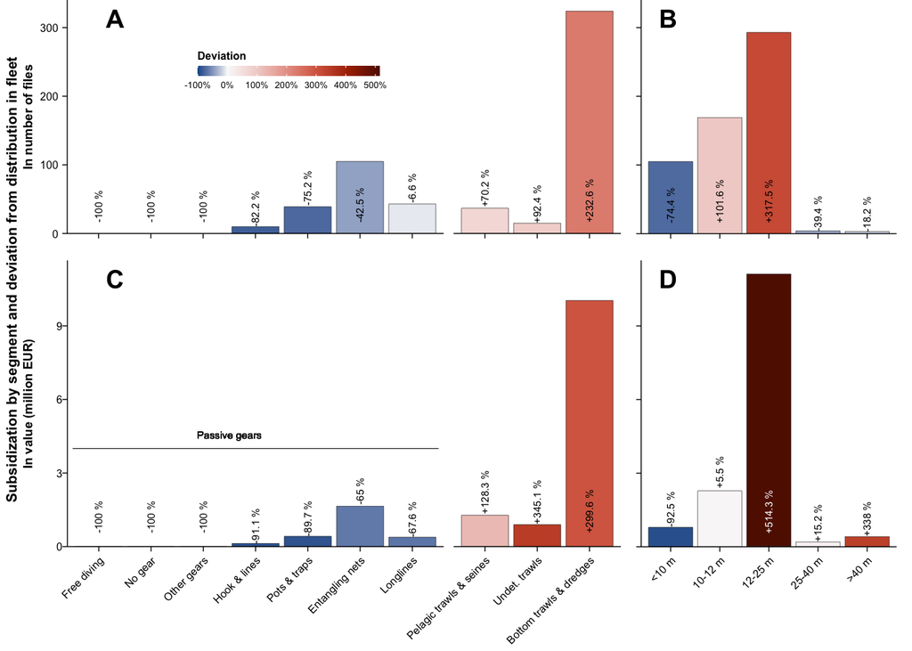

### 3.2.3 Summarizing the data

As summarized in the table above, active gears accounted for 65.5 % (376 records) and 82.5 % (12.2 million EUR) of subsidies, in number and value, respectively, although they only account for 22.1 % of the French fleet (1 384 vessels). On their own, bottom trawls & dredges accounted for 56.4 % of the subsidies (324 files), and captured 67.8 % of their amount. In contrast, passive gears only accounted for 34.3 % (197 records) and 17.5 % (2.6 million EUR) of subsidies, in number and value, respectively, although they account for 77.8 % of the French fleet. In line with these results for passive vs. active gears, vessels smaller than 10 m only accounted for 18.3 % (105 records) and 5.4 % (792 463 EUR) of the subsidies, in number and value, respectively, although they account for 71.4 % of the French fleet. In contrast, a few large vessels received substantial subsidies: the 3 vessels belonging to the >40 m class (overall accounting for 0.6 % of the national fleet) received the equivalent of 52.3 % of the amount received by the <10 m class. Adding the 4 vessels belonging to the 25-40 m class (overall accounting for 1.2 % of the fleet), this figure reaches 77 %.

Considering the European definition of ‘small-scale, coastal fisheries’, i.e. vessels smaller than 12 m and operating ‘passive gears’ (74.5 % of the French fleet), we can combine these results and say that these ‘small-scale, coastal fisheries’ only benefited from 8.7 % of the COVID fund, while vessels larger than 12 m and operating ‘active gears’, i.e. 10.7 % of the French fleet, captured 70.5 % of the COVID fund. The remaining funds, i.e. 20.7 %, were allocated to either vessels smaller than 12 m but operating ‘active’ gears (i.e. 11.5 % of the fleet), or to vessels larger than 12 m but operating ‘passive’ gears (i.e. 3.4 % of the fleet).

### 3.2.4 Plotting the same data using length instead of the number of vessels as a basis for the fleet’s distribution

| Category | Vessels in French fleet (m)* | Allocation of COVID fund Files processed (m) | Allocation of COVID fund Subsidies (EUR) |
| --- | --- | --- | --- |
| **Fishing gear** |  |  |  |
| Bottom trawls & dredges | 15 063 (24.1 %) | 5 219 (60.6 %) | 10 035 804 (67.8 %) |
| Pelagic trawls & seines | 5 404 (8.7 %) | 724 (8.4 %) | 1 279 772 (8.6 %) |
| Undet. trawls | 1 495 (2.4 %) | 323 (3.7 %) | 894 823 (6 %) |
| Entangling nets | 17 381 (27.9 %) | 1 276 (14.8 %) | 1 649 529 (11.1 %) |
| Pots & traps | 13 363 (21.4 %) | 392 (4.6 %) | 419 454 (2.8 %) |
| Hook & lines | 4 634 (7.4 %) | 126 (1.5 %) | 129 674 (0.9 %) |
| Longlines | 4 596 (7.4 %) | 548 (6.4 %) | 384 715 (2.6 %) |
| Undet. | 17 (0 %) | 9 (0.1 %) | 3 811 (0 %) |
| **Length class** |  |  |  |
| <10 m | 33 175 (53.2 %) | 902 (10.5 %) | 792 463 (5.4 %) |
| 10-12 m | 10 331 (16.6 %) | 1 934 (22.4 %) | 2 280 224 (15.4 %) |
| 12-25 m | 13 889 (22.3 %) | 5 451 (63.3 %) | 11 114 358 (75.1 %) |
| 25-40 m | 2 349 (3.8 %) | 132 (1.5 %) | 196 215 (1.3 %) |
| >40 m | 2 631 (4.2 %) | 198 (2.3 %) | 414 325 (2.8 %) |

* Note that a few marginal categories such as ‘free diving’ were not subsidized at all, hence their absence in the list and the sum of percentages slightly lower than 100%.

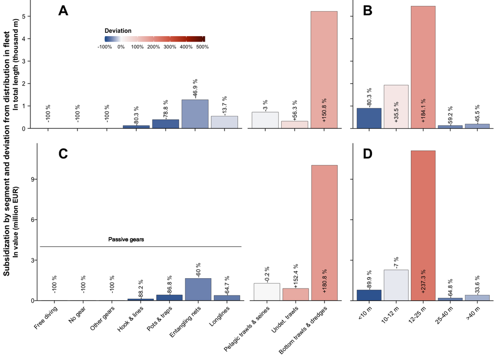

### 3.2.5 Plotting the same data using tonnage instead of the number of vessels as a basis for the fleet’s distribution

| Category | Vessels in French fleet (GT)* | Allocation of COVID fund Files processed (GT) | Allocation of COVID fund Subsidies (EUR) |
| --- | --- | --- | --- |
| **Fishing gear** |  |  |  |
| Bottom trawls & dredges | 63 402 (36.7 %) | 24 876 (66.2 %) | 10 035 804 (67.8 %) |
| Pelagic trawls & seines | 64 126 (37.1 %) | 5 038 (13.4 %) | 1 279 772 (8.6 %) |
| Undet. trawls | 7 075 (4.1 %) | 2 168 (5.8 %) | 894 823 (6 %) |
| Entangling nets | 19 382 (11.2 %) | 3 174 (8.4 %) | 1 649 529 (11.1 %) |
| Pots & traps | 7 040 (4.1 %) | 389 (1 %) | 419 454 (2.8 %) |
| Hook & lines | 2 204 (1.3 %) | 499 (1.3 %) | 129 674 (0.9 %) |
| Longlines | 9 088 (5.3 %) | 1 431 (3.8 %) | 384 715 (2.6 %) |
| Undet. | 12 (0 %) | 8 (0 %) | 3 811 (0 %) |
| **Length class** |  |  |  |
| <10 m | 12 524 (7.2 %) | 522 (1.4 %) | 792 463 (5.4 %) |
| 10-12 m | 10 963 (6.3 %) | 2 292 (6.1 %) | 2 280 224 (15.4 %) |
| 12-25 m | 64 112 (37.1 %) | 27 767 (73.9 %) | 11 114 358 (75.1 %) |
| 25-40 m | 20 295 (11.7 %) | 1 351 (3.6 %) | 196 215 (1.3 %) |
| >40 m | 65 043 (37.6 %) | 5 650 (15 %) | 414 325 (2.8 %) |

* Note that a few marginal categories such as ‘free diving’ were not subsidized at all, hence their absence in the list and the sum of percentages slightly lower than 100%.

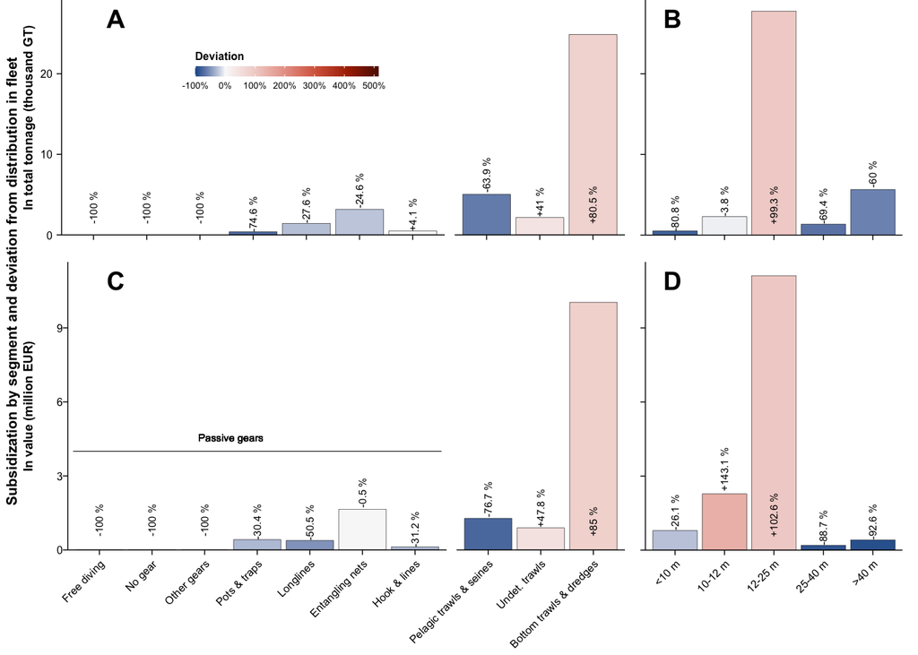

### 3.2.6 Plotting the same data using power instead of the number of vessels as a basis for the fleet’s distribution

| Category | Vessels in French fleet (kW)* | Allocation of COVID fund Files processed (kW) | Allocation of COVID fund Subsidies (EUR) |
| --- | --- | --- | --- |
| **Fishing gear** |  |  |  |
| Bottom trawls & dredges | 241 177 (25.1 %) | 91 864 (61.7 %) | 10 035 804 (67.8 %) |
| Pelagic trawls & seines | 138 741 (14.4 %) | 13 834 (9.3 %) | 1 279 772 (8.6 %) |
| Undet. trawls | 27 581 (2.9 %) | 6 862 (4.6 %) | 894 823 (6 %) |
| Entangling nets | 214 622 (22.3 %) | 19 747 (13.3 %) | 1 649 529 (11.1 %) |
| Pots & traps | 206 236 (21.5 %) | 5 594 (3.8 %) | 419 454 (2.8 %) |
| Hook & lines | 65 787 (6.8 %) | 2 502 (1.7 %) | 129 674 (0.9 %) |
| Longlines | 61 298 (6.4 %) | 8 347 (5.6 %) | 384 715 (2.6 %) |
| Undet. | 206 (0 %) | 115 (0.1 %) | 3 811 (0 %) |
| **Length class** |  |  |  |
| <10 m | 428 663 (44.6 %) | 11 565 (7.8 %) | 792 463 (5.4 %) |
| 10-12 m | 138 979 (14.5 %) | 25 386 (17.1 %) | 2 280 224 (15.4 %) |
| 12-25 m | 239 858 (25 %) | 100 975 (67.8 %) | 11 114 358 (75.1 %) |
| 25-40 m | 47 831 (5 %) | 2 639 (1.8 %) | 196 215 (1.3 %) |
| >40 m | 105 758 (11 %) | 8 300 (5.6 %) | 414 325 (2.8 %) |

* Note that a few marginal categories such as ‘free diving’ were not subsidized at all, hence their absence in the list and the sum of percentages slightly lower than 100%.

[figure not shown]

## 3.3 Larger vessels proportionately received more subsidies

### 3.3.1 Preparing the data

The first step consisted in identifying outliers using Cook’s distance (i.e. statistical individuals that significantly impact the regression):

```r
data_ratio <- data %>%
  mutate(#Calculate ratio of subsidies per unit of length/tonnage/power
    ratio_length = subsidy_total/length,
    ratio_tonnage = subsidy_total/tonnage,
    ratio_power = subsidy_total/power)
outliers <- data_ratio %>%
  mutate(#Determine outliers with Cook's distance
    id = 1:n(),
    cooks_distance_length = cooks.distance(lm(subsidy_total ~ length)),
    cooks_distance_tonnage = cooks.distance(lm(subsidy_total ~ tonnage)),
    cooks_distance_power = cooks.distance(lm(subsidy_total ~ power))) %>%
  select(id, vessel_name, length, cooks_distance_length, cooks_distance_tonnage, cooks_distance_power) %>%
  pivot_longer(cols = c(4:ncol(.)),
               names_to = "type",
               values_to = "value") %>%
  mutate(type = ifelse(grepl("length", type), "Length",
                       ifelse(grepl("tonnage", type), "Tonnage", "Power")))
outliers_vessels <- outliers %>%
  filter(value > 0.5) %>%
  select(vessel_name, length) %>%
  distinct() %>%
  arrange(length)
```

Using thresholds of 0.5 and 1, the same 3 vessels consistently showed up as outliers for `length`, `tonnage`, and `power`: CAP NORD (54.3 m), KLONDYKE (54.55 m), and DOLOMIEU (89.4 m) (not for `length`, just below the 0.5 threshold).

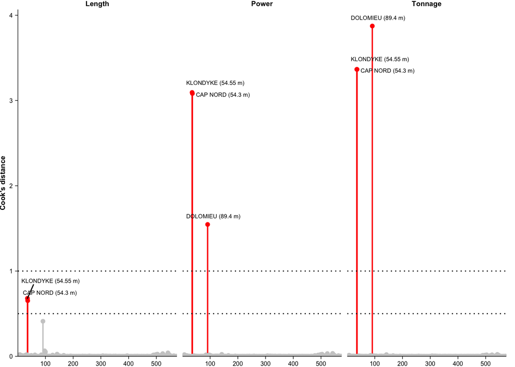

We identified these 3 vessels as outliers for the following analysis:

```r
data_ratio <- data_ratio %>%
  mutate(outlier = ifelse(!vessel_name %in% c("KLONDYKE", "DOLOMIEU") & !(vessel_name == "CAP NORD" & length == 54.30), "No", "Yes")) #There are two different 'CAP NORD'
```

Finally, we pivoted our data into longer format for plotting, and created an additional `box` column in order to create a boxplot of each class:

```r
data_ratio <- bind_rows(data_ratio %>%
                          select(length, class_length, outlier, subsidy_total, ratio_length) %>%
                          gather(key = "type", value = "subsidy", c(4:5)) %>%
                          mutate(type = ifelse(type == "subsidy_total", "Subsidy per vessel (EUR)", "Subsidy per meter (EUR)"),
                                 type = factor(type, levels = c("Subsidy per vessel (EUR)", "Subsidy per meter (EUR)"))) %>%
                          group_by(class_length) %>%
                          mutate(box = mean(c(min(floor(length)), max(ceiling(length)))),
                                 category = "Length") %>%
                          rename(value = length,
                                 class = class_length),
                        data_ratio %>%
                          select(tonnage, class_tonnage, outlier, subsidy_total, ratio_tonnage) %>%
                          gather(key = "type", value = "subsidy", c(4:5)) %>%
                          mutate(type = ifelse(type == "subsidy_total", "Subsidy per vessel (EUR)", "Subsidy per GT (EUR)"),
                                 type = factor(type, levels = c("Subsidy per vessel (EUR)", "Subsidy per GT (EUR)"))) %>%
                          group_by(class_tonnage) %>%
                          mutate(box = mean(c(min(floor(tonnage)), max(ceiling(tonnage)))),
                                 category = "Tonnage") %>%
                          rename(value = tonnage,
                                 class = class_tonnage),
                        data_ratio %>%
                          select(power, class_power, outlier, subsidy_total, ratio_power) %>%
                          gather(key = "type", value = "subsidy", c(4:5)) %>%
                          mutate(type = ifelse(type == "subsidy_total", "Subsidy per vessel (EUR)", "Subsidy per kW (EUR)"),
                                 type = factor(type, levels = c("Subsidy per vessel (EUR)", "Subsidy per kW (EUR)"))) %>%
                          group_by(class_power) %>%
                          mutate(box = mean(c(min(floor(power)), max(ceiling(power)))),
                                 category = "Power") %>%
                          rename(value = power,
                                 class = class_power))
```

### 3.3.2 Plotting the data

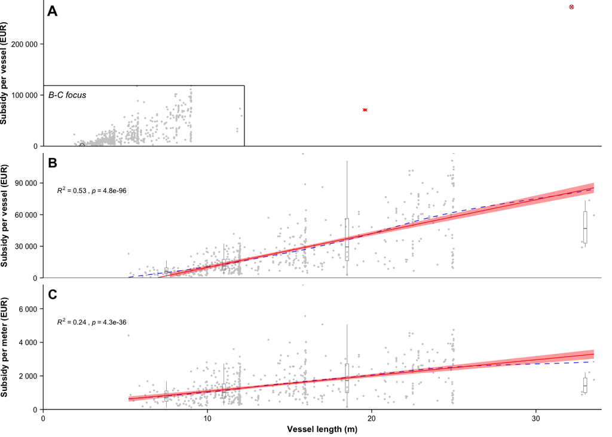

### 3.3.3 Summarizing the data

The smallest subsidy (i.e. 914 EUR) was allocated to a 6.53 m vessel. In contrast, the largest subsidy (i.e. 272 425 EUR) was allocated to the largest vessel concerned, with 89.4 m. Outliers excluded (panels B and C), vessels of the ‘<10 m’ class received a median subsidy of 6 150 EUR, while vessels between 12 and 25 m received 29 394 EUR and vessels between 25 and 40 m received 46 823 EUR (panel B). However, this increase was not regular, as panel C shows that the ratio of the subsidy received per meter also increased with the length of the vessel: while the smallest vessels below 10 m received a median of 731 EUR per meter, the 12–25 m class received 1 720 EUR and the 25-40 m class 1 408 EUR.

### 3.3.4 Plotting the data in terms of tonnage

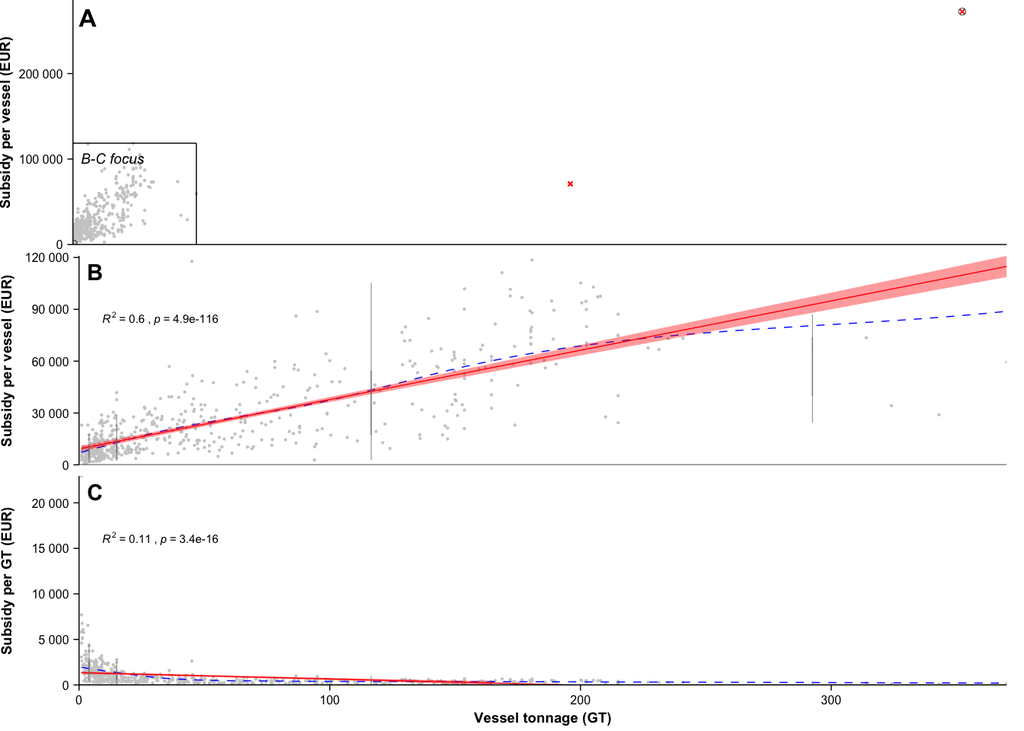

### 3.3.5 Plotting the data in terms of power

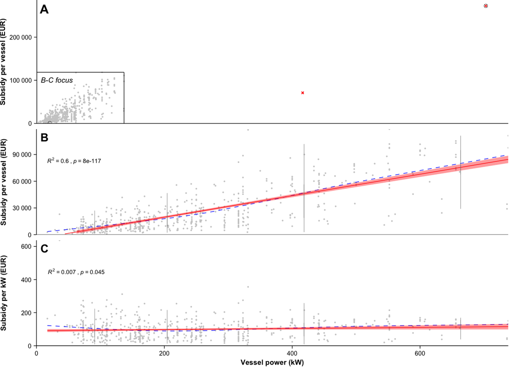

### 3.3.6 Side note on length, tonnage, and power

We used the length of the vessels as our basis for our analyses, given that this is the variable also used as a legal basis. However, we also extracted the tonnage (GT) and power (kW) of the concerned vessels, given that these two variables are used at the European level to assess the fishing fleet’s capacity (https://ec.europa.eu/oceans-and-fisheries/fisheries/rules/fishing-fleet-capacities_fr).

Here, we provide a brief analysis of the relationships between these three variables, for the `covid_fleet` data, i.e. the vessels that were active during the application of the COVID fund.

The distribution of the COVID fleet can be summarized as follows:

| Variable | Class | Number of vessels |
| --- | --- | --- |
| Length | <10 m | 4466 |
| Length | 10-12 m | 914 |
| Length | 12-25 m | 765 |
| Length | 25-40 m | 72 |
| Length | >40 m | 40 |
| Power | <165 kW | 4497 |
| Power | 165-243 kW | 894 |
| Power | 243-588 kW | 761 |
| Power | 588-1030 kW | 65 |
| Power | >1030 kW | 40 |
| Tonnage | <7 GT | 4466 |
| Tonnage | 7-23 GT | 914 |
| Tonnage | 23-213 GT | 765 |
| Tonnage | 213-370 GT | 72 |
| Tonnage | >370 GT | 40 |

First, the data show distributions that are highly right-skewed — especially for the `tonnage` variable —, i.e. the overwhelming majority of vessels are small, either in terms of length (m), tonnage (GT), or power (kW):

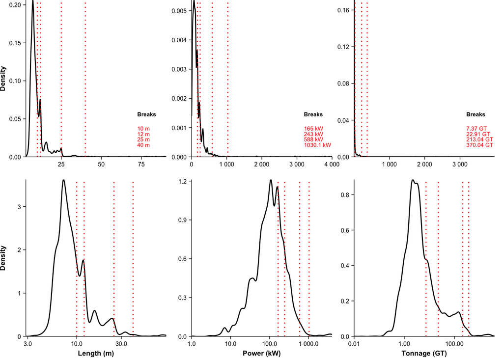

The data also show non-linear relationships between these three variables, but strong correlations:

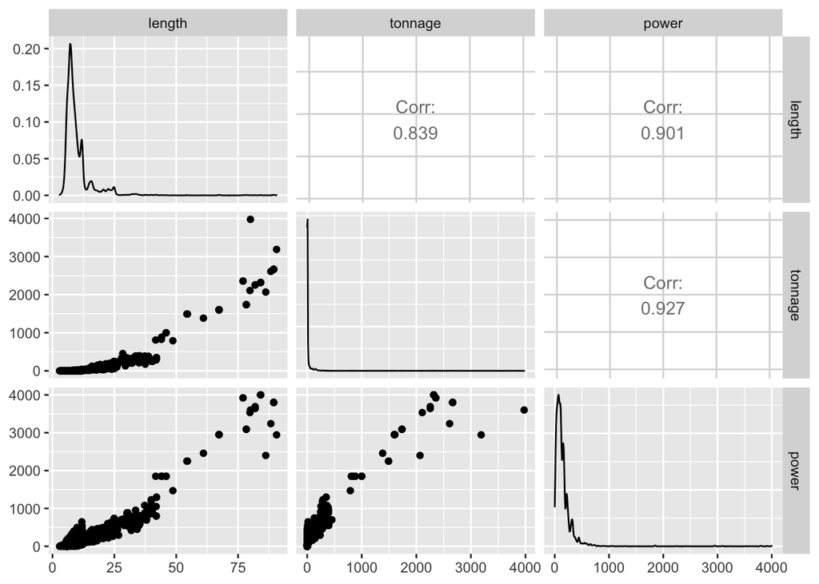

Finally, the data also show that many vessels belong to different classes for the three variables under scrutiny (particularly true for `power`).

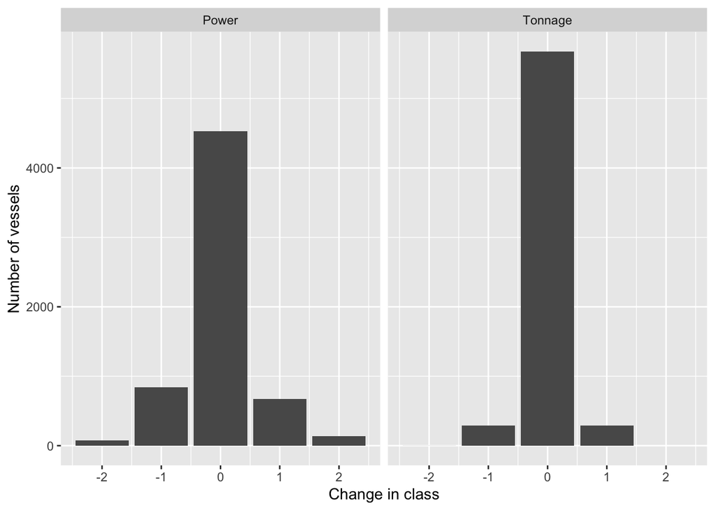